# Importing Libraries

```python
## Numpy and Pandas

import numpy as np
import pandas as pd

## Plotting libraries

import matplotlib.pyplot as plt
import seaborn as sns


## Ignore Warnings

import warnings
warnings.filterwarnings('ignore')

## Machine Learning Libraries
from sklearn.preprocessing import StandardScaler
from sklearn.model_selection import train_test_split
from sklearn.neighbors import KNeighborsClassifier
from sklearn.metrics import accuracy_score, classification_report, confusion_matrix, roc_curve, roc_auc_score
```

# Importing and Checking the data

```python
df_n = pd.read_csv('Part1 - Normal.csv')
df_h = pd.read_csv('Part1 - Type_H.csv')
df_s = pd.read_csv('Part1 - Type_S.csv')

## Cheking the shape and size of each dataset:

print('Shape of Normal Class:', df_n.shape)
print('Shape of Type_H Class:', df_h.shape)
print('shape of Type_S Class:', df_s.shape)
```

```
Shape of Normal Class: (100, 7)
Shape of Type_H Class: (60, 7)
shape of Type_S Class: (150, 7)
```

```python
## Combining the DataFrames

df = df_n.append(df_h)
df = df.append(df_s)

print('Shape of new Data Frame:', df.shape)
```

```
Shape of new Data Frame: (310, 7)
```

# Data Cleansing

```python
## Checking for null values and datatypes

df.info()
```

```
<class 'pandas.core.frame.DataFrame'>
Int64Index: 310 entries, 0 to 149
Data columns (total 7 columns):
 #   Column       Non-Null Count  Dtype
---  ------       --------------  -----
 0   P_incidence  310 non-null    float64
 1   P_tilt       310 non-null    float64
 2   L_angle      310 non-null    float64
 3   S_slope      310 non-null    float64
 4   P_radius     310 non-null    float64
 5   S_Degree     310 non-null    float64
 6   Class        310 non-null    object
dtypes: float64(6), object(1)
memory usage: 19.4+ KB
```

```python
## Checking for summary of the numeric variables

df.describe()
```

|  | P_incidence | P_tilt | L_angle | S_slope | P_radius | S_Degree |
| --- | --- | --- | --- | --- | --- | --- |
| count | 310.000000 | 310.000000 | 310.000000 | 310.000000 | 310.000000 | 310.000000 |
| mean | 60.496653 | 17.542822 | 51.930930 | 42.953831 | 117.920655 | 26.296694 |
| std | 17.236520 | 10.008330 | 18.554064 | 13.423102 | 13.317377 | 37.559027 |
| min | 26.147921 | -6.554948 | 14.000000 | 13.366931 | 70.082575 | -11.058179 |
| 25% | 46.430294 | 10.667069 | 37.000000 | 33.347122 | 110.709196 | 1.603727 |
| 50% | 58.691038 | 16.357689 | 49.562398 | 42.404912 | 118.268178 | 11.767934 |
| 75% | 72.877696 | 22.120395 | 63.000000 | 52.695888 | 125.467674 | 41.287352 |
| max | 129.834041 | 49.431864 | 125.742385 | 121.429566 | 163.071041 | 418.543082 |

##### The Data does not contain any NULL Values

##### The 6 variables that denote the biomechanics attributes are all numeric and are float variables

##### The Class variable is string type as expected. However, we need to further check the Class variable to see if the data has 3 classes as expected or has some unexpected classes or missing data that is denoted by some unexpected class

```python
## Figuring out if there are other categories in the class variable have values other than the three identified classes

df.Class.unique()
```

```
array(['Normal', 'Nrmal', 'Type_H', 'type_h', 'Type_S', 'tp_s'],
      dtype=object)
```

##### Although the 'Class' variable does not have any missing values denoted by signs such as '?' or '--' etc. It does have typos that need to be corrected

```python
## Replacing the wrong labels in the class variables

df = df.replace(to_replace='Nrmal', value='Normal')
df = df.replace(to_replace='type_h', value='Type_H')
df = df.replace(to_replace='tp_s', value='Type_S')

## Checking if all wrong labels are replaced
df.Class.unique()
```

```
array(['Normal', 'Type_H', 'Type_S'], dtype=object)
```

# Data Analysis and Visualization

### Variable by variable Analysis

```python
## Checking the column names

df.columns
```

```
Index(['P_incidence', 'P_tilt', 'L_angle', 'S_slope', 'P_radius', 'S_Degree',
       'Class'],
      dtype='object')
```

##### P_incidence

```python
## Checking the summary of P_incidence

df.P_incidence.describe()
```

```
count    310.000000
mean      60.496653
std       17.236520
min       26.147921
25%       46.430294
50%       58.691038
75%       72.877696
max      129.834041
Name: P_incidence, dtype: float64
```

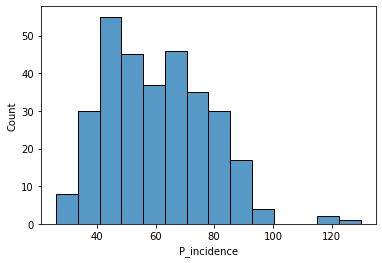

```python
## Checking the distribution of P_incidence in a histogram

sns.histplot(df.P_incidence)
```

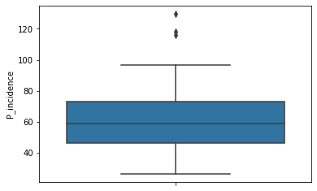

```python
## Checking the distribution of P_incidence through a boxplot


sns.boxplot(y = df.P_incidence)
```

The P_incidence data is distributed from about 26 units to about 129.8 units. When we look at the P_incidence data as a whole we see three outliers.

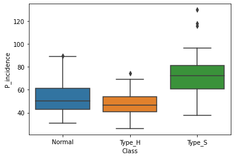

```python
## Checking the distribution of P_incidence by Class through a boxplot

sns.boxplot(x = df.Class, y=df.P_incidence);
```

```python
## ANOVA to check if Class is dependent on P_incidence

import statsmodels.api as sm
from statsmodels.formula.api import ols

mod = ols('P_incidence ~ Class', data = df).fit()
aov_table = sm.stats.anova_lm(mod, typ = 2)
print(aov_table)
```

```
                sum_sq     df          F        PR(>F)
Class     35892.191585    2.0  98.539709  8.752849e-34
Residual  55910.976950  307.0        NaN           NaN
```

since p value <0.05 we reject the Null Hypothesis that the average P_incidence for all classes is same. Therefore Class is dependent on P_incidence

```python
## Summary of P_incidence in Normal Class

df[df.Class == 'Normal'].P_incidence.describe()
```

```
count    100.000000
mean      51.685244
std       12.368161
min       30.741938
25%       42.817849
50%       50.123115
75%       61.470097
max       89.834676
Name: P_incidence, dtype: float64
```

```python
## Summary of P_incidence in Type_H Class

df[df.Class == 'Type_H'].P_incidence.describe()
```

```
count    60.000000
mean     47.638407
std      10.697131
min      26.147921
25%      41.018099
50%      46.416169
75%      53.922329
max      74.433593
Name: P_incidence, dtype: float64
```

```python
## Summary of P_incidence in Type_S Class

df[df.Class == 'Type_S'].P_incidence.describe()
```

```
count    150.000000
mean      71.514224
std       15.109337
min       37.903910
25%       60.658136
50%       72.149306
75%       81.075893
max      129.834041
Name: P_incidence, dtype: float64
```

#### If we classify the P_incidence data into the three classes we see different distributions with Type S being on the higher side and Type H being on the lower side.

#### However, there is a significant overlap in the three categories, suggesting that P_incidence alone may not be a good predictor of the class

##### P_tilt

```python
## Checking the summary of P_tilt

df.P_tilt.describe()
```

```
count    310.000000
mean      17.542822
std       10.008330
min       -6.554948
25%       10.667069
50%       16.357689
75%       22.120395
max       49.431864
Name: P_tilt, dtype: float64
```

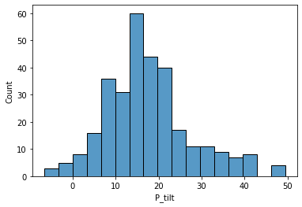

```python
## Checking the distribution of P_tilt in a histogram

sns.histplot(df.P_tilt);
```

This plot looks closer to a normal distribution

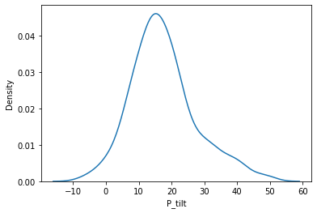

```python
## Checking the distribution of P_tilt in a kdeplot

sns.kdeplot(df.P_tilt);
```

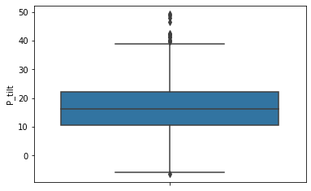

```python
## Checking the distribution of P_tilt through a boxplot

sns.boxplot(y = df.P_tilt);
```

Although the distribution of P_tilt is close to normal, it has multiple outliers both on the lower and the upper ends

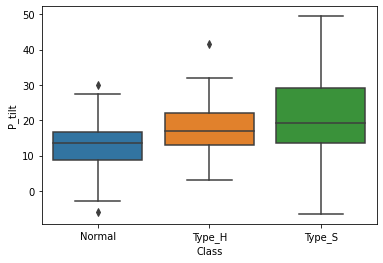

```python
## Checking the distribution of P_tilt by Class through a boxplot

sns.boxplot(x = df.Class, y = df.P_tilt);
```

```python
## ANOVA to check if Class is dependent on P_tilt

import statsmodels.api as sm
from statsmodels.formula.api import ols

mod = ols('P_tilt ~ Class', data = df).fit()
aov_table = sm.stats.anova_lm(mod, typ = 2)
print(aov_table)
```

```
                sum_sq     df          F        PR(>F)
Class      3771.425079    2.0  21.299194  2.176879e-09
Residual  27180.077360  307.0        NaN           NaN
```

since p value <0.05 we reject the Null Hypothesis that the average P_tilt for all classes is same. Therefore Class is dependent on P_tilt

#### If we classify the P_tilt data into the three classes we see that the means of the classes differ slightly with Type S being on the higher side and Normal being on the lower side.

#### However, there is a significant overlap in the three categories, suggesting that P_tilt alone may not be a good predictor of the class

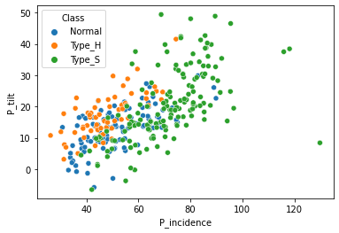

```python
## Checking the relationship of P_incidence and P_tilt along with class

sns.scatterplot(x=df.P_incidence,y=df.P_tilt, hue = df.Class);
```

```python
print('Correlation between P_incidence and P_tilt is',df.P_incidence.corr(df.P_tilt).round(2))
```

```
Correlation between P_incidence and P_tilt is 0.63
```

#### There is a strong correlation between P_incidence and P_tilt.

#### It is difficult to make out what class each patient belongs to with just these variables

##### L_angle

```python
## Checking the summary of L_angle

df.L_angle.describe()
```

```
count    310.000000
mean      51.930930
std       18.554064
min       14.000000
25%       37.000000
50%       49.562398
75%       63.000000
max      125.742385
Name: L_angle, dtype: float64
```

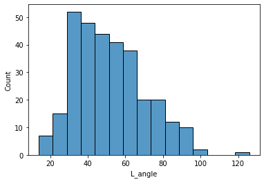

```python
## Checking the distribution of L_angle in a histogram

sns.histplot(df.L_angle);
```

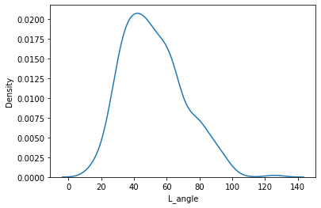

```python
## Checking the distribution of L_angle through a kdeplot

sns.kdeplot(df.L_angle);
```

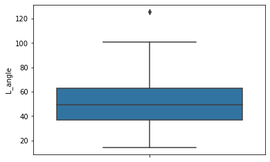

```python
## Checking the distribution of L_angle through a boxplot

sns.boxplot(y = df.L_angle);
```

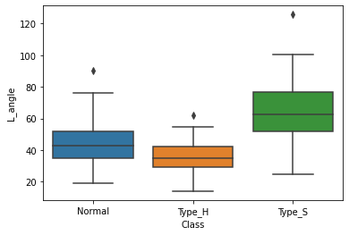

```python
## Checking the distribution of L_angle by Class through a boxplot

sns.boxplot(x = df.Class, y = df.L_angle);
```

```python
## ANOVA to check if Class is dependent on L_angle

import statsmodels.api as sm
from statsmodels.formula.api import ols

mod = ols('L_angle ~ Class', data = df).fit()
aov_table = sm.stats.anova_lm(mod, typ = 2)
print(aov_table)
```

```
                sum_sq     df          F        PR(>F)
Class     45556.786013    2.0  114.98284  5.357329e-38
Residual  60817.480453  307.0        NaN           NaN
```

since p value <0.05 we reject the Null Hypothesis that the average L_angle for all classes is same. Therefore Class is dependent on L_angle

#### If we classify the L_angle data into the three classes we see that the means of the classes differ with Type S being on the higher side and Type_H being on the lower side.

#### However, there is a significant overlap in the three categories, suggesting that L_angle alone may not be a good predictor of the class

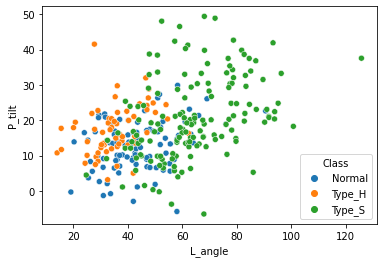

```python
## Checking the relationship of L_angle and P_tilt along with class

sns.scatterplot(x=df.L_angle,y=df.P_tilt, hue = df.Class);
```

#### In the current dataset it seems that patients with L_angle greater than 70 and P_tilt greater than 30 all belong to Type_S

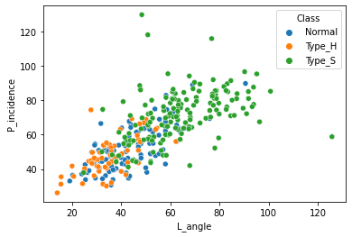

```python
## Checking the relationship of L_angle and P_incidence along with class

sns.scatterplot(x=df.L_angle,y=df.P_incidence, hue = df.Class);
```

#### L_angle seems to have a positive correlation with both P_tilt and P_incidence. With P_incidence the correlation seems to be stronger. However, in the plot with P_tilt we start to see some predictability for the class to which the patient belongs.

```python
print('Correlation between P_incidence and L_angle is',df.L_angle.corr(df.P_incidence).round(2))
print('Correlation between P_tilt and L_angle is',df.L_angle.corr(df.P_tilt).round(2))
```

```
Correlation between P_incidence and L_angle is 0.72
Correlation between P_tilt and L_angle is 0.43
```

##### S_slope

```python
## Checking the summary of S_slope

df.S_slope.describe()
```

```
count    310.000000
mean      42.953831
std       13.423102
min       13.366931
25%       33.347122
50%       42.404912
75%       52.695888
max      121.429566
Name: S_slope, dtype: float64
```

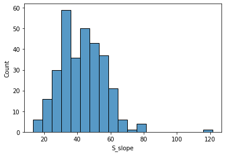

```python
## Checking the distribution of S_slope in a histogram

sns.histplot(df.S_slope);
```

The distribution of S_slope looks like a normal curve with an outlier on the right side

```
(<AxesSubplot:xlabel='S_slope', ylabel='Density'>,)
```

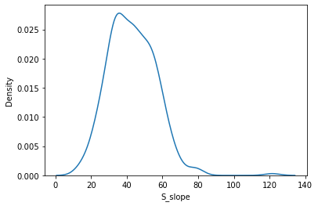

```python
## Checking the distribution of S_slope in a kdeplot

sns.kdeplot(df.S_slope),
```

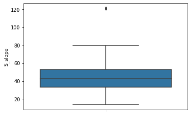

```python
## Checking the distribution of S_slope through a boxplot

sns.boxplot(y=df.S_slope);
```

It's more or less an even distribution except for an outlier

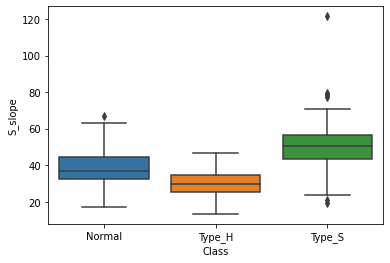

```python
## Checking the distribution of S_slope by Class through a boxplot

sns.boxplot(x= df.Class, y=df.S_slope);
```

```python
## ANOVA to check if Class is dependent on S_Slope

import statsmodels.api as sm
from statsmodels.formula.api import ols

mod = ols('S_slope ~ Class', data = df).fit()
aov_table = sm.stats.anova_lm(mod, typ = 2)
print(aov_table)
```

```
                sum_sq     df          F        PR(>F)
Class     20526.825851    2.0  89.643953  2.175670e-31
Residual  35148.692713  307.0        NaN           NaN
```

since p value <0.05 we reject the Null Hypothesis that the average S_slope for all classes is same. Therefore Class is dependent on S_slope

#### If we classify the S_slope data into the three classes we see that the means of the classes differ with Type S being on the higher side and Type_H being on the lower side.

#### However, there is an overlap in the three categories, suggesting that S_slope alone may not be a good predictor of the class

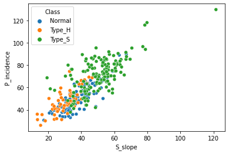

```python
## Checking the relationship of S_slope and P_incidence along with class

sns.scatterplot(x=df.S_slope,y=df.P_incidence,hue = df.Class);
```

```python
print("Correlation between S_slope and P_incidence is",df.S_slope.corr(df.P_incidence).round(2))
```

```
Correlation between S_slope and P_incidence is 0.81
```

S_slope has a strong correlation with P_incidence

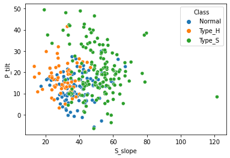

```python
## Checking the relationship of S_slope and P_tilt along with class

sns.scatterplot(x=df.S_slope,y=df.P_tilt,hue=df.Class);
```

```python
print("Correlation between S_slope and P_tilt is",df.S_slope.corr(df.P_tilt).round(2))
```

```
Correlation between S_slope and P_tilt is 0.06
```

S_slope has almost no correlation with P_tilt

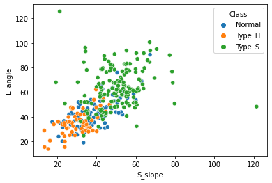

```python
## Checking the relationship of S_slope and L_angle along with class

sns.scatterplot(x=df.S_slope,y=df.L_angle,hue=df.Class);
```

```python
print("Correlation between S_slope and L_angle is",df.S_slope.corr(df.L_angle).round(2))
```

```
Correlation between S_slope and L_angle is 0.6
```

S_slope has a strong correlation with L_angle

It is difficult to predict the class by just observing the scatterplots of S_slope with other variables studied till now

##### P_radius

```python
## Checking the summary of P_radius

df.P_radius.describe()
```

```
count    310.000000
mean     117.920655
std       13.317377
min       70.082575
25%      110.709196
50%      118.268178
75%      125.467674
max      163.071041
Name: P_radius, dtype: float64
```

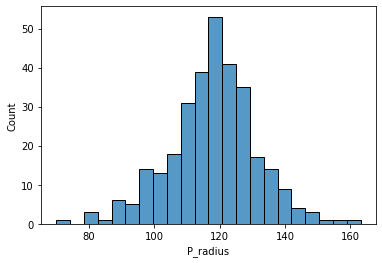

```python
## Checking the distribution of P_radius in a histogram

sns.histplot(df.P_radius);
```

The distribution for P_radius looks normal

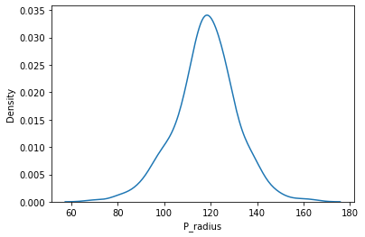

```python
## Checking the distribution of P_radius in a kdeplot

sns.kdeplot(df.P_radius);
```

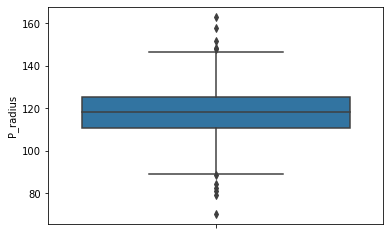

```python
## Checking the distribution of P_radius through a boxplot

sns.boxplot(y=df.P_radius);
```

There are some outliers in the distribution of P_radius

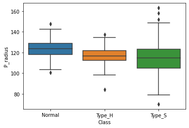

```python
## Checking the distribution of P_radius by Class through a boxplot

sns.boxplot(x=df.Class,y=df.P_radius);
```

```python
## ANOVA to check if Class is dependent on P_radius

import statsmodels.api as sm
from statsmodels.formula.api import ols

mod = ols('P_radius ~ Class', data = df).fit()
aov_table = sm.stats.anova_lm(mod, typ = 2)
print(aov_table)
```

```
                sum_sq     df          F        PR(>F)
Class      5425.586931    2.0  16.866935  1.121996e-07
Residual  49376.345258  307.0        NaN           NaN
```

since p value <0.05 we reject the Null Hypothesis that the average P_radius for all classes is same. Therefore Class is dependent on P_radius

##### While the average values of P_radius differ for the three classes, the overlap between the distribution is high.

```python
print("Correlation between P_radius and P_incidence is",df.P_radius.corr(df.P_incidence).round(2))
print("Correlation between P_radius and P_tilt is",df.P_radius.corr(df.P_tilt).round(2))
print("Correlation between P_radius and L_angle is",df.P_radius.corr(df.L_angle).round(2))
print("Correlation between P_radius and S_slope is",df.P_radius.corr(df.S_slope).round(2))
```

```
Correlation between P_radius and P_incidence is -0.25
Correlation between P_radius and P_tilt is 0.03
Correlation between P_radius and L_angle is -0.08
Correlation between P_radius and S_slope is -0.34
```

There is a weak to moderate negative correlation between P_radius with P_incidence and S_slope respectively and almost no correlation with P_tilt and L_angle

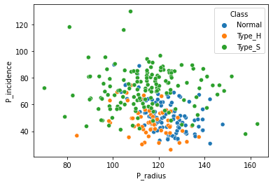

```python
## Checking the relationship of P_radius and P_incidence along with class

sns.scatterplot(x=df.P_radius,y=df.P_incidence,hue=df.Class);
```

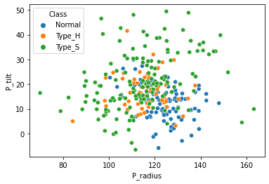

```python
## Checking the relationship of P_radius and P_tilt along with class

sns.scatterplot(x=df.P_radius,y=df.P_tilt,hue=df.Class);
```

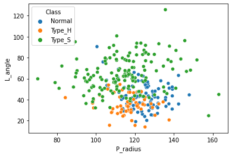

```python
## Checking the relationship of P_radius and L_angle along with class

sns.scatterplot(x=df.P_radius,y=df.L_angle,hue=df.Class);
```

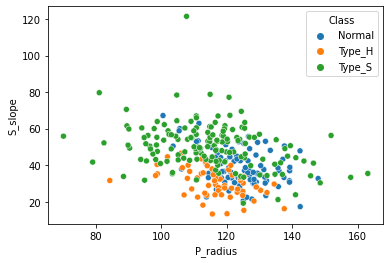

```python
## Checking the relationship of P_radius and S_slope along with class

sns.scatterplot(x=df.P_radius,y=df.S_slope,hue=df.Class);
```